# MA/MAEP Career Placement Meeting 1

McMaster Department of Economics

Chris Muris

18 September 2026

[figure not shown]

*[jobs.scotiabank.com, requisition 273081](https://jobs.scotiabank.com/job/Toronto-GBM-Client-Insights-&-Analytics-InternshipCo-op-Fall-2027-%2812-Months%29-ON/605902117/)*

## Another one, closing 4 November

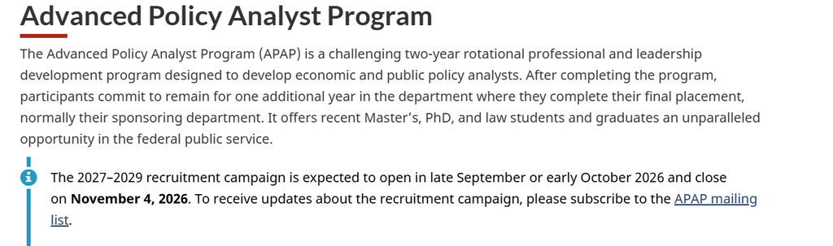

Federal. [Advanced Policy Analyst Program](https://www.canada.ca/en/treasury-board-secretariat/topics/professional-development/advanced-policy-analyst-program.html). Rotations through four departments, starting July 2027.

## And one closing 25 September

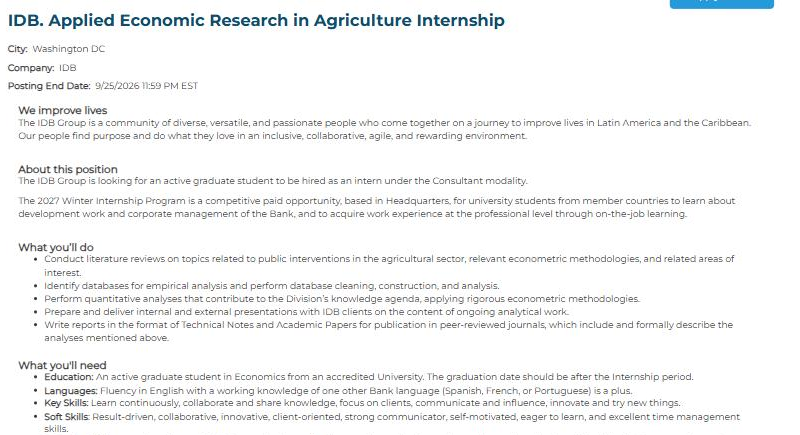

International. [Inter-American Development Bank, Winter 2027 internship](https://jobs.iadb.org/job/IDB_-Applied-Economic-Research-in-Agriculture-Internship/3485-en_US), Washington. Open to graduate students who are nationals of a member country, and Canada is one.

## And one closing 7 October

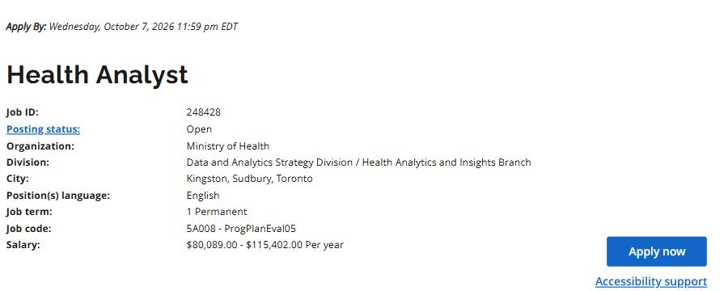

Provincial. [Ontario Ministry of Health, Health Analyst](https://www.gojobs.gov.on.ca/Preview.aspx?JobID=248428). Read the salary band and the “lead” language: this one suits someone a few years further on.

# This is normal

Early recruitment is not confined to government.

- **Scotiabank:** applications close **5 October 2026** to start **Sep 2027**.
- **[Deloitte Economics Advisory](https://careers.deloitte.ca/job/AnalystConsultant-Economics-Advisory-New-Grad-2027-Multiple-Locations/134580-en_US/):** applications due **18 September 2026** to start **Sep 2027**.
- **APAP:** closing date is **4 November 2026**, for a **July 2027** start.

**Read the conditions as well as the dates.** A future start does not mean every current student qualifies.

My sweep of the boards on 17 September found **106 postings closing in September or October**, and **69 of them stated conditions a current MA or MAEP student could meet**. Only 10 of those 69 were public sector.

## What that sweep actually found

# Placement

Part One

What is “placement”, what I do, and **what you do**.

# “Placement” is the wrong word

- “Placement” is about whatever you are going to do during your co-op and after you complete your degree.
- I coordinate the meetings, circulate opportunities, and nudge. **You search and apply.** I don’t assign jobs, or “place” you.
- Searching, applying and interviewing involve **skills you can learn**. Practising them is part of your work this year.
- So my job this year is to give you the **information** and the **reason to start practising early**. The practice is yours.

# Four meetings

- Today: orientation, timing, where to look.
- **Friday 2 October, 12:30, KTH104**: CVs and cover letters. **Bring a two-page CV and a one-page cover letter.**
- First week of Winter term: co-op, WIL and the spring search.
- Date to follow: interview preparation.

## How you will hear from me

- **Placement emails.** I send opportunities as they arrive, and they are time-sensitive. Apply when one fits rather than saving them up.
- **These slides and every link** go on my website after today.
- **Recruiter visits and careers events** during the year. Come with a question ready.
- **Meet any time.** Email me and we will find a slot.

# Why now

- **Some opportunities have early deadlines.** Missing a recruitment cycle can mean waiting for the next one. Missing the APAP deadline means your APAP dream can not start until **July 2028**.
- **Preparation takes time.** Referees need notice; good applications need revision.
- **You can start before you have a final career plan.** Investigate possibilities and practise explaining what you can contribute.

# Where economists land

Part Two

Examples of the work, **why you might want it**, and what the employer needs.

# What you want, and what they want

- You have preferences about what comes next. **So does every employer**, and both sides have to be satisfied before anything happens.
- You will think plenty about your own half. Give the same attention to **the employer’s needs**: start with the work and qualifications in the posting.
- Next up: five possibilities, and **what would make a good match**.

# Federal

*Example: [Advanced Policy Analyst Program](https://www.canada.ca/en/treasury-board-secretariat/topics/professional-development/advanced-policy-analyst-program.html).*

- **The work:** analyze public policy through placements in central agencies and a department.
- **Why you might want it:** contribute to policy in Canada and learn how decisions are made across government.
- **What they want:** analytical ability, good judgment and an interest in public policy.

**Imagine that you want this placement. What would you have to do over the next month to qualify? What would you do over the next few months to maximize your chances?**

## Federal: other ways in

Programmes that recruit economists most years. Check each page for updated details.

**Graduate programmes.** [APAP](https://www.canada.ca/en/treasury-board-secretariat/topics/professional-development/advanced-policy-analyst-program.html) at Treasury Board Secretariat, closing 4 November. [DND Policy Officer Recruitment](https://www.canada.ca/en/department-national-defence/corporate/job-opportunities/civilian-jobs/civilian-job-opportunities/students-and-new-grads/policy-officer-recruitment-programme.html), a two-week window in the fall. [NRCan Policy Analyst Recruitment and Development](https://natural-resources.canada.ca/corporate/careers/policy-analyst-recruitment-development-program), with starts in May, September and January. [Statistics Canada EC recruitment](https://www.statcan.gc.ca/en/employment/recruit/ec/ec), entering at EC-02 and graduating at EC-04.

**Student routes that may lead to a job.** [FSWEP](https://www.canada.ca/en/public-service-commission/jobs/services/recruitment/students/federal-student-work-program.html), a year-round inventory. [Post-Secondary Co-op and Internship](https://www.canada.ca/en/public-service-commission/jobs/services/recruitment/students/coop-internship.html), arranged through the department. [Research Affiliate Program](https://www.canada.ca/en/public-service-commission/jobs/services/recruitment/students/research-affiliate-program.html), part-time research while you study. Afterwards a department can hire you without a new competition, which they call [student bridging](https://www.canada.ca/en/public-service-commission/services/appointment-framework/student-bridging.html).

**Everything else** is in Appendix A: departments, agencies, regulators and Crown corporations. Ordinary vacancies are posted on [GC Jobs](https://emploisfp-psjobs.cfp-psc.gc.ca/psrs-srfp/applicant/page2440?fromMenu=true&toggleLanguage=en).

## Federal: where ours went

- **ZV**, MA ’22, analyst at the **Parliamentary Budget Officer**, costing the proposals that get debated in the House.
- **DD**, MA ’20, economist at **Statistics Canada**.
- **MT**, MA ’17, started at **Finance Canada**, then moved to **Fisheries and Oceans**, then to **Housing, Infrastructure and Communities**, as a senior policy adviser and acting manager.
- **HC**, MA ’11, taught economics first, then became an economist at the **Canada Revenue Agency**.
- **BK**, MA ’22, analyst at **Statistics Canada**, then senior economist at the **Conference Board of Canada**.

The pattern worth noticing: **where you start does not fix where you end up.** Moving between departments is normal, and moving out to a think tank or the private sector is common too.

## Federal: what is good, and what is not

**Good**

- **Scale and mobility.** Hundreds of teams, and moving between them is routine.
- **Training built in.** The development programmes rotate you on purpose.
- **Published pay.** APAP hires at EC-03, $77,690 to $87,907, and graduates at EC-05, roughly $100,000 to $115,000.
- **The work matters**, and you see how decisions actually get made.

**Not so good**

- **Slow.** Months from application to offer, with exams, interviews, references and security screening.
- **Status gates.** Citizens and permanent residents come first, and some streams require citizenship.
- **Ottawa and Gatineau**, mostly. Relocation is expected for the development programmes.
- **Language.** Many economist roles in the National Capital Region are bilingual imperative.
- **Rigid progression.** Pay and promotion follow the classification, not your performance in a given year.

# Other government

*Example: the [Ontario Internship Program](https://www.ontario.ca/page/careers-ontario-internship-program), policy development.*

- **The work:** research policy questions and help develop options for a provincial ministry.
- **Why you might want it:** work on the services and policies that affect people in the province.
- **What you could show:** a project that uses evidence to compare options and explains the implications clearly.

**Imagine a ministry comparing two ways to deliver a service. What could your economics training contribute?**

## Other government: other ways in

Dates from the 17 September sweep, so check each page.

**Entry programmes.** [Ontario Internship Program](https://www.ontario.ca/page/careers-ontario-internship-program), applications December to January, salary $57,085, and open to work permit holders. [Toronto Urban Fellows](https://www.toronto.ca/home/jobs/information-for-applicants/recruitment-initiatives/toronto-urban-fellows/), for recent master’s graduates, next intake spring 2027, open work permit accepted. [OLIP](https://www.olipinterns.ca/apply-to-olip) at Queen’s Park and [PIP](https://www.uottawa.ca/faculty-social-sciences/political-studies/pip/application-information) in Ottawa both open 1 December and close 31 January, and both require citizenship or permanent residence.

**Ordinary vacancies.** [Ontario Public Service careers](https://www.gojobs.gov.on.ca/Jobs.aspx) posts everything, so search it directly for economist, policy analyst and research analyst. Other provinces run their own boards, and British Columbia, Alberta, Manitoba and Nova Scotia all hire economists. Municipal: [City of Toronto](https://jobs.toronto.ca/jobsatcity/), [City of Hamilton](https://www.hamilton.ca/city-council/jobs-city), the regions, and the transit agencies.

**Crown corporations.** [AIMCo](https://aimco.wd10.myworkdayjobs.com/AIMCoCareers/job/Calgary/Student--Economics---Investment-Research--May-2027-_JR100900) in Alberta, Hydro One, Ontario Power Generation, Ontario Lottery and Gaming, the Workplace Safety and Insurance Board, BC Hydro. Port authorities look local but are federal.

**Everything else** is in Appendix A.

## Other government: where ours went

- **MS**, MA ’22, senior economist with the **Government of Alberta**.
- **PN**, MA ’16, started at the **British Columbia Securities Commission**, then CMHC, and is now a senior economist at the **Ontario Securities Commission** and the Labour Market Information Council.

## Other government: what is good, and what is not

**Good.** The work sits close to services people actually use, and you see the result within a year rather than a decade. Hiring is less formal than federal, so a strong application can move quickly. These employers are generally **more open to work permit holders**: the Ontario Internship Program accepts a valid permit, and Toronto’s Urban Fellows accepts an open permit. Pay is respectable, with the Ontario analyst band at $80,089 to $115,402. And the jobs are spread across the province rather than concentrated in one capital.

**Not so good.** There is no single calendar, so postings appear without warning and you have to look. Ads that do not gate on years of experience attract experienced applicants, so an entry-level candidate competes against people with five years. The internships that are genuinely entry-level have narrow windows, December and January, and the legislative ones require citizenship or permanent residence. Dedicated economist titles are rarer here than federally, so the work often sits inside a policy or analyst role.

# International organizations

*Example: [IDB, Applied Economic Research in Agriculture internship](https://jobs.iadb.org/job/IDB_-Applied-Economic-Research-in-Agriculture-Internship/3485-en_US).*

- **The work:** analyze agricultural policy using data, econometrics and research reports.
- **Why you might want it:** apply economics to development questions in Latin America and the Caribbean.
- **What they want:** applied econometrics and Stata experience, careful work with data, and the ability to communicate results.

**Could you explain one empirical project from the raw data to the conclusion?**

## International organizations: who they are

- **Multilateral banks:** [World Bank](https://www.worldbank.org/ext/en/careers), [IMF](https://www.imf.org/en/About/Recruitment), [Inter-American Development Bank](https://jobs.iadb.org), [EBRD](https://www.ebrd.com/careers-at-the-ebrd.html), Asian Development Bank, African Development Bank.
- **Policy and research bodies:** [OECD](https://www.oecd.org/en/about/careers.html), [Bank for International Settlements](https://www.bis.org/careers/vacancies.htm), the WTO.
- **UN agencies:** [UNDP](https://www.undp.org/careers), UNICEF, [ILO](https://jobs.ilo.org/content/Working-at-the-ILO/?locale=en_GB), [WHO](https://www.who.int/careers), the World Food Programme, FAO, UNCTAD.
- **Research institutes:** IFPRI and the rest of CGIAR, which hire research analysts for development economics.

Longer list in **Appendix A**.

**The work, in general.** Applied research and evaluation: cleaning and analyzing survey or administrative data, running the econometrics, writing technical notes and briefs, and supporting country teams. Stata or R, and often a language beyond English. Titles to look for: research analyst, research assistant, consultant, intern, and young professional.

**You have to go looking.** Nobody circulates these. Each organization runs its own board, postings appear without warning and close quickly, and many are term contracts rather than permanent jobs. Pick three organizations, bookmark their boards, and check them monthly.

# Private sector

*Example: [Deloitte, Economics Advisory, New Grad 2027](https://careers.deloitte.ca/job/AnalystConsultant-Economics-Advisory-New-Grad-2027-Multiple-Locations/134580-en_US/).*

- **The work:** input-output, cost-benefit and CGE modelling for advisory work.
- **Why you might want it:** use economic analysis to answer concrete questions for clients.
- **What they want:** economics training and experience with Excel and EViews or R. Show a model you can explain, including its assumptions and limitations.

**What decision would your analysis help the client make?**

## Private sector: who hires economists

- **Banks and capital markets:** RBC, TD, BMO, Scotiabank, CIBC, National Bank, Desjardins. Economics departments, risk, pricing, and the trading floor.
- **Pensions and asset managers:** CPP Investments, Ontario Teachers’, OMERS, HOOPP, IMCO, Brookfield, Mackenzie.
- **Insurance:** Manulife, Sun Life, Intact, Co-operators, Aviva.
- **Consulting:** the Big Four for economics advisory and transfer pricing, and the economic consultancies, Charles River Associates, Analysis Group, Brattle, Compass Lexecon, where a PhD is often preferred.
- **Energy and climate:** E3, Dunsky, Enbridge, Suncor, the utilities.
- **Telecom, tech and retail:** Bell, Rogers, Telus, Shopify, Canadian Tire, Loblaw, and the large platforms.
- **Health economics:** the pharmaceutical companies, EVERSANA, ICES, and the health technology agencies.
- **Ratings and data:** Fitch, Moody’s, S&P.

Longer list in **Appendix A**, including credit unions, think tanks and the less obvious employers.

## Private sector: what was open this month

From the 17 September sweep. They close quickly, which is the point.

- **[Deloitte](https://careers.deloitte.ca/job/AnalystConsultant-Economics-Advisory-New-Grad-2027-Multiple-Locations/134580-en_US/)**, Economics Advisory, new graduate 2027. Closes 18 September.
- **Bell**, 2027 Graduate Program, “bachelor’s or master’s … in Economics”, 30-month rotation. Closes 16 November.
- **Manulife**, Winter 2027 co-op, quantitative analyst, master’s students. Closes 5 October.
- **Ontario Teachers’**, capital markets quantitative research interns, master’s or PhD. Closes 22 September.
- **OMERS**, six Winter 2027 student roles. Closes 21 September.
- **Doane Grant Thornton**, transfer pricing, new graduate. Closes 4 October.
- **Hatch**, three new-graduate roles. Closes 30 September.

**The pattern:** two to four weeks from posting to deadline, most of them for a start a year later, and almost none of them mention citizenship.

# Further study

*Example: an economics PhD and an application for research funding.*

- **The work:** pursue a research question over several years, with much more independence than in coursework.
- **Why you might want it:** you enjoy developing questions and investigating them in depth.
- **What you need to demonstrate:** preparation for research, a clear explanation of your interests, and evidence that your referees can discuss.

**Which question would you want to keep working on after the course ends?**

## Further study: the routes, and where ours went

**The routes.** Our own PhD, which the MA has a stream into. PhDs elsewhere, in Canada, the United States and Europe, with applications closing in December and January. **Pre-doctoral research jobs**, which have become the standard step: research assistant at the [Bank of Canada](https://www.bankofcanada.ca/careers/students/), the [IMF research analyst programme](https://www.imf.org/en/About/Recruitment), or with a professor here. And professional programmes: law, an MBA, or a master’s in public policy.

**Where ours went.** LP, MA ’10, and LS, MA ’12, both took PhDs and are now professors of economics. On the PhD side, TV, PhD ’18, teaches and now works as a data scientist, and GG, PhD ’17, is an assistant director at the Canadian Research Data Centre Network. A PhD does not commit you to academia.

**What actually decides it.** Not your average alone. Two professors who can write in detail about your research, a question you can describe in a paragraph, and, increasingly, a year or two of pre-doctoral work.

# Look past these five

**Those five categories are a starting point.**

- Our own graduates are at a securities regulator, an airline’s pricing team, a housing agency, a national statistical office, a think tank, a retailer’s analytics team, two universities, and two companies they founded themselves.
- **RM**, analyst at Canadian Tire, then founded a sports-analytics company, and is now doing a PhD.
- **RT**, MA into a PhD, then two companies, and has just sold the second, which used economics and machine learning for marketing.

**Your first job does not settle your career.**

# The categories

- **Federal**
- **Provincial, municipal and Crown corporations**
- **International organizations**
- **Private sector**
- **Further study**
- And **co-op and work-integrated learning**, which is a way into the others.

**Keep an open mind.** People who arrived certain about the Bank of Canada leave wanting consulting, and the reverse happens just as often.

**But each one asks for different things, at different times.** Up next.

# Timing and eligibility

Part Three

What each of those routes asks of you, and **when**.

# The deadlines that matter

- **A fixed campaign:** APAP announces **4 November 2026** as its closing date and **July 2027** as its start.
- **An employer’s deadline:** [Deloitte’s economics advisory graduate role](https://careers.deloitte.ca/job/AnalystConsultant-Economics-Advisory-New-Grad-2027-Multiple-Locations/134580-en_US/) closes **18 September 2026** for **fall 2027**.
- **A student placement:** check the work dates against your enrolment and coursework, not just the application deadline.
- **Further study:** track programme admission and scholarship deadlines separately; ask about internal deadlines. Think ahead about reference letters.

## Federal applications: where to begin

- **Ordinary vacancies:** search [GC Jobs](https://www.canada.ca/en/services/jobs/opportunities/government.html). Read the area of selection and answer every screening question with evidence.
- **Graduate programmes:** [APAP](https://www.canada.ca/en/treasury-board-secretariat/topics/professional-development/advanced-policy-analyst-program.html), [DND PORP](https://www.canada.ca/en/department-national-defence/corporate/job-opportunities/civilian-jobs/civilian-job-opportunities/students-and-new-grads/policy-officer-recruitment-programme.html), [NRCan PARDP](https://natural-resources.canada.ca/corporate/careers/policy-analyst-recruitment-development-program) and [Statistics Canada](https://www.statcan.gc.ca/en/employment/recruit/ec/ec) have their own rules and calendars.
- **Department of Finance:** its [annual recruitment page](https://www.canada.ca/en/department-finance/corporate/jobs/recruitment.html) currently says **on hold**.
- **Bank of Canada:** use its own [student and graduate careers page](https://www.bankofcanada.ca/careers/students/). Master’s economist/analyst interviews are described as taking place in October and November; use the vacancy for the application deadline.

## Federal selection and assessments

- Read each process’s stages and instructions. You may be asked for screening answers, tests, interviews, references and security information.
- Give referees notice and keep a record of what you submitted. Follow the assessment named in the invitation.
- One possible assessment is the Test of Judgement 376: **52 multiple-choice questions in 90 minutes**. It is not a test required for every federal job.
- Ask about development and later mobility within the organization. Your first role need not define your whole career.

## APAP: dates and eligibility

[Programme and application requirements](https://www.canada.ca/en/treasury-board-secretariat/topics/professional-development/advanced-policy-analyst-program.html)

- General campaign expected to open late September or early October; announced close **4 November 2026**. Interviews **January 2027**; offers **April/May**; start **July 2027**.
- Canadian citizen or permanent resident; bachelor’s degree plus qualifying master’s, PhD or law degree by **1 June 2028**. Required coursework completed by **1 June 2027**.
- Course requirements: one half-year micro, one half-year macro, two additional half-year economics courses, and one half-year statistics, quantitative analysis or research-methods course (specified full-year equivalents accepted).
- Strong academic achievement and willingness to relocate to the National Capital Region. Read all conditions on the programme page.
- The **Indigenous Inventory is a separate route**, with different requirements and a **2 November 2026** closing date.

## Provincial and municipal applications

- Search [Ontario Public Service careers](https://www.gojobs.gov.on.ca/Jobs.aspx) and the portals of other provinces and municipalities. Look beyond Ontario.
- [Ontario Internship Program](https://www.ontario.ca/page/apply-ontario-internship-program): the published recruitment pattern begins in December, with applications December/January. **Check the new cycle’s graduation window and dates.**
- OIP accepts valid work authorization covering the internship; applicants must meet its other conditions too.
- [Toronto Urban Fellows](https://www.toronto.ca/home/jobs/information-for-applicants/recruitment-initiatives/toronto-urban-fellows/): check the current intake, recent-graduate rules and work authorization.
- Read the duties as well as the degree requirement. A role asking you to lead teams may be a later career step.

## Legislative internships

- [Ontario Legislature Internship Programme](https://www.olipinterns.ca/apply-to-olip): the 2027/28 intake opens **1 December 2026**, closing **31 January 2027**. Check degree-completion and citizenship/permanent-residence conditions.
- [Parliamentary Internship Programme](https://www.uottawa.ca/faculty-social-sciences/political-studies/pip/application-information): check the forthcoming 2027/28 application dates and referee deadline on its page.
- These programmes have their own entry rules; they are not interchangeable with OIP or a generic government co-op.

## International applications: read the particular programme

- Use the organization’s own careers page. Distinguish internships, direct vacancies and young-professional programmes.
- The [IDB agriculture internship](https://jobs.iadb.org/job/IDB_-Applied-Economic-Research-in-Agriculture-Internship/3485-en_US) closes **25 September 2026**, for **16 January/15 March 2027**.
- It requires member-country nationality, continuing graduate enrolment and **at least 50% of graduate coursework completed when applying**, alongside substantial technical requirements. A new September entrant should not assume eligibility.
- It asks for fluent English; another Bank language is a plus. Read each role’s language requirements separately.
- [UN YPP](https://careers.un.org/young-professionals-programme?language=en) has its own nationality, age and qualification rules. [World Bank YPP](https://www.worldbank.org/ext/en/careers/talent-programs/young-professionals-program) requires professional experience; do not treat every YPP as a first job after an MA.

## Private-sector applications

- Search employer careers pages as well as job boards; do not rely on a vacancy being forwarded to you.
- Tailor your evidence to the duties. Check the seniority, location, start date and work-authorization conditions.
- The [Deloitte economics advisory example](https://careers.deloitte.ca/job/AnalystConsultant-Economics-Advisory-New-Grad-2027-Multiple-Locations/134580-en_US/) asks for a cover letter, CV and unofficial transcript in **one PDF**. Follow the instructions of each employer.
- For the [Scotiabank year-long placement](https://jobs.scotiabank.com/job/Toronto-GBM-Client-Insights-%26-Analytics-InternshipCo-op-Fall-2027-%2812-Months%29-ON/605902117/), check that the term fits your programme and enrolment. The ad also specifies technical skills; enrolment alone is not sufficient.
- Ask what the interview assesses. Similar titles can involve different combinations of economics, programming and communication.

## Further study: decide what you are applying for

- For an economics PhD, compare research fields and prospective supervision. Discuss your preparation and goals with your professors.
- Consider other fields and professional programmes too: public policy, health policy, business, law or medicine.
- Check each programme’s prerequisites and **GRE, LSAT or MCAT policy**. Requirements vary; allow time for any required test and score reporting.
- Ask referees early. Give them your work, a draft statement, the programme list and deadlines.
- A pre-doctoral research role is another possibility to investigate. Keep other options open while you assess the fit.

## Research funding: check both calendars

- **University funding:** read the offer and programme funding policy; ask which awards need separate applications.
- **CGRS-M:** **$27,000 for one year**, deadline **1 December**. Check the [current eligibility rules](https://nserc-crsng.canada.ca/en/funding-opportunity/canada-graduate-research-scholarship-masters-program), including citizenship/permanent residence/protected status and months of study.
- **CGRS-D:** **$40,000 per year for three years**. McMaster lists **22 September 2026, 11:59 p.m.** for [SSHRC doctoral submissions](https://gs.mcmaster.ca/current-students/scholarships/sshrc-doctoral-scholarships-and-fellowships/). Ask your programme whether an earlier local deadline applies.
- **OGS:** international students may be eligible, but apply through the applicable departmental process. Ask about nomination, grades and time-in-programme limits. **Do not assume an unsuccessful federal application is automatically transferred.**
- Check the agency appropriate to your research, and the current limits on multiple applications. Foundations and subject-specific awards are additional possibilities listed by SGS.

# Not everything is urgent

- **FSWEP** accepts applications to an ongoing student inventory. Individual hiring still has its own requirements.
- **Federal co-op** opportunities arrive employer by employer through participating schools.
- Set a regular time to check vacancies and update your applications. **No single deadline means you need your own routine.**

## Student routes into federal work

- [FSWEP](https://www.canada.ca/en/public-service-commission/jobs/services/recruitment/students/federal-student-work-program.html): an ongoing inventory; keep your profile current and check student eligibility.
- [Co-op/Internship](https://www.canada.ca/en/public-service-commission/jobs/services/recruitment/students/coop-internship.html): placements through participating academic programmes and institutions.
- [Research Affiliate Program](https://www.canada.ca/en/public-service-commission/jobs/services/recruitment/students/research-affiliate-program.html): research opportunities linked to academic study.
- [Student bridging](https://www.canada.ca/en/public-service-commission/services/appointment-framework/student-bridging.html) can provide a route to later employment. A placement does not guarantee a permanent appointment.

## Co-op and WIL: the decisions to make

- Investigate placements yourself as well as reading department emails. Prepare before the January meeting; employers may advertise earlier.
- Compare a co-op with any permanent offer on the actual work, pay, benefits and effect on your degree.
- Discuss work-term dates and programme completion with the graduate administrator. A later placement can extend your studies; do not assume one duration fits everyone.
- You may compete with applicants from other disciplines. Demonstrate what your economics training adds.
- Meeting 3 covers the mechanics. Read the current Graduate Calendar before committing to a placement.

## Co-op and WIL: degree requirements

- The WIL stream uses **ECON 796 and ECON 797**. It is **for credit**, so you stay registered full time and pay tuition during the work term, and each term needs a report. Confirm the current requirements with the graduate administrator.
- Completing only 796 does **not** mean losing the master’s degree: students who leave WIL return to the regular stream. Both courses are needed for the WIL designation.
- Plan for the report and evaluation required for each course. Agree dates with the programme; do not assume the end of the job is the end of the course.
- International students should obtain advice about work authorization and the effect of placement dates on their study plans.

# Finding and pursuing the other routes

- **Provincial and municipal:** watch the relevant employer portals and internship programmes; check the level of each job.
- **Private sector:** follow employers as well as job boards. Match your evidence to the duties and follow the file instructions.
- **International organizations:** use their own careers pages. Check nationality, enrolment and language conditions for each vacancy.
- **Further study:** compare departments and research interests; ask potential referees early and check admissions and funding separately.

# Keep the preparation moving

- **Put the deadline and required documents in a tracker** when you find an opportunity.
- **Work backwards:** allow time for references, transcripts, tests and revisions.
- **Set aside time every week.** Finding suitable roles and tailoring applications are part of the work.
- **Do not wait for Meeting 2** if a suitable opportunity closes sooner. Watch placement emails regularly.

# Who can apply where

- **Citizenship, work authorization and student status are different questions.** Check all that apply.
- **Federal routes differ:** a programme may restrict entry; a competition may give preference to citizens and permanent residents.
- **Other employers and international organizations have their own rules.** Check the actual vacancy, including location and language requirements.

## Eligibility: federal and other employers

- In advertised external appointments under the [Public Service Employment Act, section 39](https://laws-lois.justice.gc.ca/eng/acts/p-33.01/FullText.html), preference applies to qualifying veterans and then Canadian citizens and permanent residents. Citizens and permanent residents share that category.
- A programme can impose narrower conditions. APAP is one example; read its own requirements.
- Federal student programmes prefer citizens and permanent residents; international students may be considered when no eligible, qualified Canadian students are available. Read the [student-employment rules](https://www.canada.ca/en/government/publicservice/workforce/staffing/mobility/student-employment-programs-federal-government.html).
- Bank of Canada, CRA and parliamentary employers use their own hiring arrangements. Read the vacancy; a different legal framework does not imply no citizenship preference.
- Security screening and citizenship are separate checks. **Do not assume every Secret-clearance position is citizens-only.**

## Language and work authorization

- A federal posting states whether the role is English essential, French essential or bilingual, and the required profile.
- **Bilingual imperative** requires the specified proficiency at appointment. **Non-imperative** staffing may permit language training under the applicable conditions.
- Use the [official language requirements guidance](https://www.canada.ca/en/public-service-commission/jobs/services/gc-jobs/language-requirements-candidates.html); there is no single language profile for every economist or analyst role.
- A Canadian study permit, a Canadian work permit and authorization to work abroad are different things. Check the role’s location and your permission to work there.

## International students: planning after graduation

- Talk to Cynthia.
- Eligible master’s graduates from programmes of at least **eight months** may receive a **three-year PGWP**, subject to the other rules and passport validity. It is not automatic.
- University graduates need language results at **CLB/NCLC 7 in all four skills**. Apply within **180 days** of completing the programme and meet the other eligibility conditions. Master’s degrees have no field-of-study requirement.
- Since **1 April 2026**, eligible post-secondary students do not need a separate co-op permit for required placements. Study-permit and placement conditions still apply; check them before starting work.
- Use [IRCC’s PGWP eligibility page](https://www.canada.ca/en/immigration-refugees-citizenship/services/study-canada/work/after-graduation/eligibility.html) and [placement guidance](https://www.canada.ca/en/immigration-refugees-citizenship/services/study-canada/work/intern.html), and ask McMaster’s immigration advisers about your situation.
- Do not extend a master’s simply on the assumption that a longer programme produces a longer PGWP.

# What to do now

Part Four

Your next steps, starting **this week**.

# Writing is what gets you read

**What you write this year:** a one-page **cover letter** per application, a two-page **CV** you re-tailor each time, **written answers to federal screening questions**, and a one-page **research statement** for funding or a PhD.

**Writing that becomes evidence:** a course or work-term **report or memo** you can send as a sample, and anything **public**, a project page, a short write-up, a GitHub repository.

- **Write for the reader’s decision:** why interview you, or fund your research?
- **Show evidence.** Not “strong quantitative skills”, but the project, your part in it, and what it established.
- **Revise for clarity.** Use the posting’s terms accurately, explain your reasoning, proofread.

**Speaking comes in Meeting 4**, and it gets easier once the writing is clear. Making yourself write a persuasive page is the best interview practice I know.

## Writing and revising your application

- Start with the reader’s question. Explain what you did and why it matters for this opportunity.
- Use a concrete example: the question, your contribution, the result and its limitations. A course list alone leaves the reader to infer your abilities.
- Adapt a reusable draft to each application. HR and the eventual supervisor may need different levels of explanation.
- Use short sentences and ordinary words. Check grammar, including articles; avoid elaborate language that obscures the point.
- Expect several revisions. Ask a reader what they understood before asking them to correct the wording.
- More on this in Meeting 2.

## Writing resources and AI

- Arthur’s suggested reading: Deirdre McCloskey, *Economical Writing*; Eugene Ehrlich, *Schaum’s Outline of English Grammar*; Strunk and White, *The Elements of Style*. Look for these through the library.
- For articles: [Cambridge Dictionary, a/an/the](https://dictionary.cambridge.org/grammar/british-grammar/a-an-and-the).
- Optional listening: CBC *Under the Influence*, [Selling Yourself: The Art of Personal Branding](https://www.cbc.ca/radio/undertheinfluence/selling-yourself-the-art-of-personal-branding-1.3106068).
- Use AI to ask practice questions, critique clarity or suggest alternatives. Check every factual statement and retain your own argument. **Jevon’s paradox.**
- Follow the employer’s AI rules. Do not upload someone else’s draft or personal information without permission. AI-generated examples and feedback can be wrong.

# Your next steps

1. **Today or tomorrow:** choose one opportunity. Check eligibility and the deadline; identify what the employer or programme needs.
2. **This week:** put its requirements in a tracker and start gathering evidence. Apply before its deadline, even if that is before Meeting 2.
3. **By Friday 2 October:** bring a **two-page CV and one one-page cover letter**, tailored to that opportunity, to Meeting 2. Bring the posting too.

# Four things to take away

If you remember nothing else

1. **Start now.** The jobs you want after graduating are being advertised already.
2. **Own it.** I circulate and advise. You apply.
3. **Practise.** Searching, writing and interviewing are skills you can improve.
4. **Write with the employer in front of you.** Every posting says what it wants. Answer that.

# Appendix A: places to investigate

Examples for extending your search. **These are not a list of current vacancies or a statement that you qualify.** Check each employer’s careers page.

## Federal Government

### Central agencies and other economic institutions

- Department of Finance Canada
- Bank of Canada
- Statistics Canada
- Parliamentary Budget Officer
- Privy Council Office
- Treasury Board of Canada Secretariat

### Key Economic & Social Departments

- Innovation, Science and Economic Development Canada
- Employment and Social Development Canada
- Environment and Climate Change Canada
- Natural Resources Canada
- Fisheries and Oceans Canada
- Health Canada
- Public Health Agency of Canada
- Immigration, Refugees and Citizenship Canada
- Transport Canada
- Agriculture and Agri-Food Canada

### Regulators & Other Bodies

- Competition Bureau
- Office of the Superintendent of Financial Institutions
- Canadian Radio-television and Telecommunications Commission
- Canadian Transportation Agency

### Other federal organizations

- Canada Mortgage and Housing Corporation
- Export Development Canada
- Business Development Bank of Canada
- Canada Infrastructure Bank
- Invest in Canada
- Vancouver Fraser Port Authority

## Provincial & Municipal Government

### Provincial Finance & Central Agencies

- Ministries of Finance such as Ontario, British Columbia, Alberta, and Quebec
- Treasury Boards
- Provincial statistical agencies such as Institut de la statistique du Quebec and British Columbia Stats

### Provincial Line Ministries & Regulators

- Health, Labour, Education, Energy, Environment, Transportation
- Provincial financial regulators such as the Financial Services Regulatory Authority of Ontario
- Energy regulators such as the Ontario Energy Board and the Alberta Utilities Commission

### Municipalities & Regional Bodies

- Large cities such as Toronto, Vancouver, Calgary, and Montreal
- Regional governments such as Peel Region and York Region
- Transit bodies such as Metrolinx, TransLink, and the Toronto Transit Commission

### Utilities, compensation and housing bodies

- Utilities such as British Columbia Hydro, Hydro-Quebec, and Ontario Power Generation
- Workers’ compensation boards such as the Workplace Safety and Insurance Board and WorkSafeBC
- Tarion Warranty Corporation

## Asset Management & Pensions

- CPP Investments
- Caisse de depot et placement du Quebec
- Ontario Teachers’ Pension Plan
- Public Sector Pension Investment Board
- Ontario Municipal Employees Retirement System
- Healthcare of Ontario Pension Plan
- OPTrust
- Alberta Investment Management Corporation
- British Columbia Investment Management Corporation
- Investment Management Corporation of Ontario
- Brookfield Asset Management
- Onex
- Power Corporation
- Mackenzie Investments

## International Organizations

- **Multilateral institutions**
  - World Bank
  - International Monetary Fund
  - Organisation for Economic Co-operation and Development
- **United Nations Agencies:** United Nations Children’s Fund, International Labour Organization, World Health Organization, United Nations Development Programme, World Food Programme
- **Regional Development Banks:** Asian Development Bank, European Bank for Reconstruction and Development, Inter-American Development Bank

## Private Sector

### Banking & Financial Services

- **Bank Economics Departments:** Royal Bank of Canada, Toronto-Dominion Bank, Scotiabank, Bank of Montreal, Canadian Imperial Bank of Commerce, National Bank of Canada, Desjardins
- **Capital Markets and Investment Banking:** Quantitative and strategy roles
- **Insurance:** Manulife, Sun Life, Intact Financial, Co-operators, Aviva
- **Credit Unions:** Meridian Credit Union, Alterna Savings, FirstOntario Credit Union, Vancity, Servus Credit Union, Desjardins Group
- **Credit Union Centrals and Infrastructure:** Central 1, Atlantic Central, Alberta Central, SaskCentral, Credit Union Central of Manitoba
- **Trust and Retirement Administration:** Concentra Trust, Equitable Bank

### Consulting

- **Economic consulting** (check the degree requirement for each role)
  - Analysis Group, Charles River Associates, The Brattle Group, Compass Lexecon
- **Management/Strategy Consulting**
  - McKinsey & Company, Boston Consulting Group, Bain & Company
- **“Big 4” & Policy Shops**
  - Deloitte, PricewaterhouseCoopers, Ernst & Young, KPMG (economics and policy advisory)
  - MNP Economics, Copenhagen Economics
- **Other consultancies**
  - Accenture, CGI, Nous Group, Mercer, TELUS Health

### Industry & Corporate Roles

- **Tech, Data, and Telecommunications:** Shopify, Bell Canada, Rogers, TELUS, eBay, Uber, Amazon, Netflix, Microsoft, Google, Meta
- **Retail and Consumer Packaged Goods:** Canadian Tire, Loblaw, Shoppers Drug Mart, Couche-Tard
- **Transportation and Energy:** Air Canada, Canadian National Railway, Canadian Pacific Kansas City, Enbridge, Suncor, Hydro One
- **Other major employers:** Walmart, Boeing, SickKids, Kids Help Phone
- **Health Economics and Pharmaceuticals:** Pfizer Canada, GlaxoSmithKline, Novartis, ICES, Canada’s Drug Agency (CDA-AMC)

## Third Sector & Research

### Think Tanks & Policy Institutes

- C.D. Howe Institute
- Conference Board of Canada
- Institute for Research on Public Policy
- Fraser Institute
- Broadbent Institute

### Non-profits, NGOs & Associations

- Sector associations such as the Canadian Bankers Association and the Canadian Chamber of Commerce
- Canadian Credit Union Association
- Insurance Bureau of Canada
- Large NGOs

# Appendix B: search and support

Use the links that fit your search. Check the current service or event’s eligibility and registration conditions.

## Where postings live

**Not an exhaustive list**, and it will go out of date. These are the boards that produced real economics postings when I last checked them.

General

- [LinkedIn Jobs](https://www.linkedin.com/jobs/): search “economist”, “economic analyst”, “policy analyst”, filter to entry level
- [Indeed Canada](https://ca.indeed.com/): same searches, set alerts
- [Job Bank](https://www.jobbank.gc.ca/home) (Government of Canada)
- [OSCARplus](https://oscarplusmcmaster.ca/home.htm) (McMaster)
- [Workforce Planning Hamilton](https://www.workforceplanninghamilton.ca/jobs/) (Hamilton region)

Economics-specific

- [CABE jobs board](https://cabe.ca/jobs-board/)
- [Canadian Economics Association employment exchange](https://www.economics.ca/jobs-employment-exchange) (mostly academic)

Government

- [GC Jobs](https://emploisfp-psjobs.cfp-psc.gc.ca/psrs-srfp/applicant/page2440?fromMenu=true&toggleLanguage=en) (federal)
- [Bank of Canada job board](https://careers.bankofcanada.ca/go/All-Job-Opportunities/2400817/)
- [Ontario Public Service careers](https://www.gojobs.gov.on.ca/Jobs.aspx)
- [City of Toronto jobs](https://jobs.toronto.ca/jobsatcity/), [City of Hamilton jobs](https://www.hamilton.ca/city-council/jobs-city)

Sector boards

- [Credit Union Careers](https://creditunioncareers.ca/)

Bookmark the careers pages of the ten employers you most want to work for and check them weekly.

**Found something good that is not here? Tell me.** I will check it and pass it on to the next cohort of McMaster MA and MAEP students, and to this one.

## Networking and recruiter visits

- Use alumni paths to discover roles you had not considered. Ask for an informational conversation, not an assumption of a job.
- Attend recruiter visits and job fairs prepared. Ask about the work and the evidence successful applicants provide.
- Explore [CABE](https://cabe.ca/) and its [Toronto chapter, TABE](https://cabe.ca/chapters/tabe/). Check the event fee and current student arrangements before registering.
- Contacts through volunteering, previous jobs and family can help you learn about workplaces. Follow the employer’s application procedure.
- Consider an unsolicited approach where the organization invites one; tailor it as carefully as a response to a posting.

## McMaster support

- [Graduate career counselling and job-search coaching](https://studentsuccess.mcmaster.ca/grad-students/careers/): book through [OSCARplus](https://oscarplusmcmaster.ca/home.htm), which also carries postings and events.
- [School of Graduate Studies career development](https://gs.mcmaster.ca/current-students/resources/career-and-professional-development/): training, mentoring and support links. Check registration and eligibility for the service you want.
- [MacConnect](https://socialsciences.careers.mcmaster.ca/career-planning/job-search/platforms/macconnect/): connect with alumni and learn about their paths.
- [Alumni career services](https://alumnicareerservices.mcmaster.ca/): check the support available after graduation.
- [International student immigration advising](https://studentsuccess.mcmaster.ca/international-students/immigration-advising/): immigration@mcmaster.ca.

## Hamilton support

- Start with the City’s [International Students and Graduates](https://hamiltonimmigration.ca/internationalstudents/) page and its *International Grad Guide to Thriving in Hamilton*.
- [Workforce Planning Hamilton](https://www.workforceplanninghamilton.ca/jobs/) provides a local job board.
- [Fedcap Canada](https://www.fedcapcanada.org/jobseekers) helps you locate employment-service providers. Check the provider’s eligibility conditions and any fees.
- [Helping International Students events](https://events.helpinginternationalstudents.com/event-list): explore community events and opportunities to meet people.
- For entrepreneurship, investigate [The Forge](https://theforge.mcmaster.ca/) and [Innovation Factory](https://innovationfactory.ca/). Check programme requirements before applying.